# Some Simple JAGS Examples

Chris Haid

April 3, 2014

First, lets get some prerequisites out of the way.

```r
require(rjags)
```

```r
require(coda)
require(igraph)
```

### Normally distrubted data with unknown mean and variance

Create some simulated data:

```r
set.seed(432104)
n <- 1000
x <- rnorm(n, 0, 5)
```

Most `JAGS`/`BUGS` examples save the probability model in a separate file and then read it in in the call to `JAGS`. Below we’ll use the function `textConnection` to pass a string object *as if it were a text file*. The benefit is we can keep the probability model inline with the rest of our R code which helps makes this document self-contained).

```r
model1.string <-"
  model {
    for (i in 1:N){
    x[i] ~ dnorm(mu, tau)
    }
  mu ~ dnorm(0,.0001)
  tau <- pow(sigma, -2)
  sigma ~ dunif(0,100)
}
"
model1.spec<-textConnection(model1.string)
```

Now we pass `rajgs` the model, data, and other options to run four MCMC chains to estimate the paramters of interest in the the model. The update step is unnecessary and I’m just making sure it works. The `jags.samples` function samples from the samples and calculates means.

```r
jags <- jags.model(model1.spec,
                   data = list('x' = x,
                               'N' = n),
                   n.chains=4,
                   n.adapt=100)
```

```
##    Graph Size: 1009
##
```

```r
update(jags, 1000)

jags.samples(jags,
             c('mu', 'tau'),
             1000)
```

```
## $mu
## mcarray:
## [1] 0.04038
##
## Marginalizing over: iteration(1000),chain(4)
##
## $tau
## mcarray:
## [1] 0.03851
##
## Marginalizing over: iteration(1000),chain(4)
```

### SAT Example

Here’s an example from Chapter 5 fo Gelman and Hill. Data is simple: change in SAT average SAT scores at 8 schools as well as the standerd devations of the difference in the mean SAT scores. The question Gelman is interested in answering is: do different SAT training programs have a positive effect on SAT scores?

Here’s the data, where $\sigma$ (`sigma`) is the standard deviation and `schoolobs` are the observed change in means, $\mu$:

```r
sigma     <- c(15,10,16,11, 9,11,10,18)
schoolobs <- c(28,8, -3, 7,-1, 1,18,12)
```

Gelman’s recommendation is a multi-level model where mean training effect is drawn from a mean zero normal distribtion, a school’s indiviudal effect is drawn from normal distribution with with the mean equal to the mean training effect, and the observed scores (realizations) are then drawn from a distribtion paramaterized with the mean given by the individual school effect. The model is given by:

```r
model.sat.text<-"
  model {
    for(i in 1:N) {
    schoolmean[i] ~ dnorm(mu,itau)
    thes[i] <- 1/pow(sigma[i],2)
    schoolobs[i] ~ dnorm(schoolmean[i],thes[i])
    }

  mu ~ dnorm(0,alpha)
  alpha <- .01
  itau   ~ dgamma(1e-3,pow(15,2)*1e-3)
  tau <- pow(1/itau,1/2)
}
"
model.sat.spec<-textConnection(model.sat.text)
```

This probability model can be represented graphically like so (note that the `y1` are the observed schools difference in means, `schoolobs`):

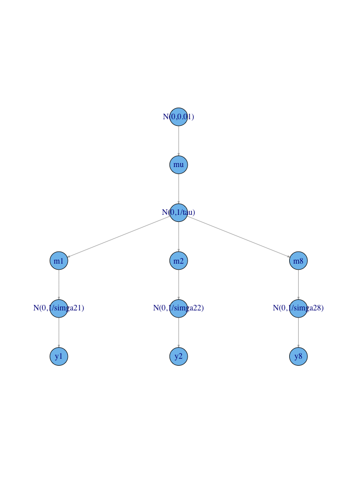

```r
gr<-graph.formula("N(0,0.01)"-+"mu",
                  "mu"-+"N(0,1/tau)",
                  "N(0,1/tau)"-+"m1",
                  "N(0,1/tau)"-+"m2",
                  "N(0,1/tau)"-+"m8",
                  "m1"-+"N(0,1/simga21)",
                  "m2"-+"N(0,1/simga22)",
                  "m8"-+"N(0,1/simga28)",
                  "N(0,1/simga21)"-+"y1",
                  "N(0,1/simga22)"-+"y2",
                  "N(0,1/simga28)"-+"y8")


lo<-data.frame(x=c(2,2,2,1,2,3,1,2,3,1,2,3),y=c(6,5,4,3,3,3,2,2,2,1,1,1))
plot(gr,
     layout=layout.reingold.tilford(gr),
     edge.arrow.size=.25
     )
```

To estimate the unobserved parameters we send the model and data it to `JAGS` and get the MCMC chains back.

```r
sat.jags <- jags.model(model.sat.spec,
                       data=list('sigma'=sigma,
                                 'schoolobs'=schoolobs,
                                 'N'=length(schoolobs)
                                 ),
                       n.chains=4,
                       n.adapt = 1000)
```

```
##    Graph Size: 49
##
```

```r
#run with jags.samples
samps.jags <- jags.samples(sat.jags,
                           c('mu','tau'),
                           n.iter=10000,
                           thin=10
                           )

samps.jags
```

```
## $mu
## mcarray:
## [1] 6.557
##
## Marginalizing over: iteration(1000),chain(4)
##
## $tau
## mcarray:
## [1] 3.328
##
## Marginalizing over: iteration(1000),chain(4)
```

```r
#same thing but return a coda MCMC object
samps.coda <- coda.samples(sat.jags,
                           c('mu','tau', 'schoolmean'),
                           n.chains=4,
                           n.iter=10000,
                           thin=10
                           )

head(samps.coda)
```

```
## [[1]]
## Markov Chain Monte Carlo (MCMC) output:
## Start = 10010
## End = 10070
## Thinning interval = 10
##         mu schoolmean[1] schoolmean[2] schoolmean[3] schoolmean[4]
## [1,] 6.858         4.441         6.884         3.399         4.912
## [2,] 6.651         4.819         7.618         7.758         7.249
## [3,] 6.717         7.132         6.222         7.252         6.707
## [4,] 6.256         6.434         6.580         5.960         6.352
## [5,] 7.651        10.075         7.668         7.491         8.679
## [6,] 7.274         7.397         4.849         4.939        10.374
## [7,] 7.482         8.136         6.237         8.484         7.031
##      schoolmean[5] schoolmean[6] schoolmean[7] schoolmean[8]    tau
## [1,]         6.216         3.928         4.432         4.700 2.9018
## [2,]         4.848         7.521         6.343         7.944 1.3805
## [3,]         6.207         7.440         6.728         7.514 0.6310
## [4,]         6.625         6.095         6.223         6.662 0.3224
## [5,]         4.899         7.302         7.871         8.255 1.1717
## [6,]         9.327         8.130         6.322         7.262 2.9332
## [7,]        10.756         8.601         8.666         3.932 1.7384
##
## [[2]]
## Markov Chain Monte Carlo (MCMC) output:
## Start = 10010
## End = 10070
## Thinning interval = 10
##            mu schoolmean[1] schoolmean[2] schoolmean[3] schoolmean[4]
## [1,] 13.38122        6.3954         6.208     15.534067       16.2113
## [2,] 14.12215       26.6097        16.228      0.002633        6.6225
## [3,]  4.99123        5.7026        10.428      2.669832        8.1851
## [4,]  0.06915        6.0449        -3.886      0.051299        3.7487
## [5,]  5.19878       -0.9787         2.949     -0.925401        2.8301
## [6,] 11.48402        9.2527        10.729     11.622515       12.6712
## [7,] -0.69545        7.8712       -13.112    -12.050189       -0.7314
##      schoolmean[5] schoolmean[6] schoolmean[7] schoolmean[8]   tau
## [1,]         7.564       14.7133        14.357       11.7343 7.802
## [2,]         1.312        1.1712        22.031        8.4149 6.255
## [3,]         9.030        4.9098         7.139        0.4624 3.088
## [4,]        -5.955       -0.5888         4.795        8.6685 5.307
```

[output cut: 35 more lines]

```
## [4,]  5.199         4.725         5.276         4.524         5.820
## [5,]  6.257         4.578         7.174         5.880         5.028
## [6,] -2.810        -4.473        -4.388        -5.011         3.946
## [7,] -3.809        -2.623        -8.387       -14.313        -2.874
##      schoolmean[5] schoolmean[6] schoolmean[7] schoolmean[8]   tau
## [1,]       17.9277       18.4197       15.9240       16.5010 1.771
## [2,]       13.2176        9.2908       11.5295        9.5858 2.670
## [3,]        4.5521       11.5822       17.2689        9.1727 5.952
## [4,]        5.0433        5.7591        4.8974        4.0290 0.483
## [5,]        5.2204        6.4176        5.2694        4.9177 1.550
## [6,]       -0.3299        0.9276        2.6981       -3.8604 2.834
## [7,]       -4.8161        9.8330        0.4226        0.4757 8.372
##
## attr(,"class")
## [1] "mcmc.list"
```

```r
summary(samps.coda)
```

```
##
## Iterations = 10010:20000
## Thinning interval = 10
## Number of chains = 4
## Sample size per chain = 1000
##
## 1. Empirical mean and standard deviation for each variable,
##    plus standard error of the mean:
##
##               Mean   SD Naive SE Time-series SE
## mu            6.51 4.01   0.0634         0.1233
## schoolmean[1] 7.97 5.66   0.0896         0.1369
## schoolmean[2] 6.74 5.03   0.0796         0.1217
## schoolmean[3] 5.93 5.68   0.0897         0.1401
## schoolmean[4] 6.59 5.03   0.0795         0.1237
## schoolmean[5] 5.56 5.03   0.0795         0.1396
## schoolmean[6] 5.92 5.08   0.0803         0.1356
## schoolmean[7] 7.90 5.27   0.0834         0.1280
## schoolmean[8] 6.92 5.56   0.0879         0.1322
## tau           3.40 3.60   0.0569         0.0797
##
## 2. Quantiles for each variable:
##
##                 2.5%  25%  50%   75% 97.5%
## mu            -1.468 3.87 6.41  9.16  14.5
## schoolmean[1] -1.598 4.33 7.47 11.02  20.9
## schoolmean[2] -2.830 3.60 6.56  9.81  16.9
## schoolmean[3] -6.609 2.80 6.08  9.37  16.2
## schoolmean[4] -3.281 3.48 6.50  9.68  16.5
## schoolmean[5] -5.566 2.62 5.75  8.96  14.7
## schoolmean[6] -4.835 2.98 6.05  9.13  15.5
## schoolmean[7] -1.194 4.43 7.52 10.88  19.8
## schoolmean[8] -3.589 3.60 6.71 10.07  18.8
## tau            0.413 1.08 2.19  4.39  13.1
```

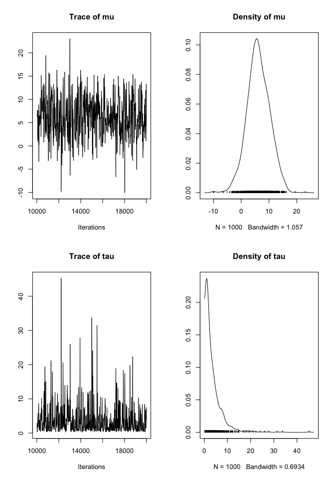

```r
plot(samps.coda[[1]][,c("mu","tau")])
```

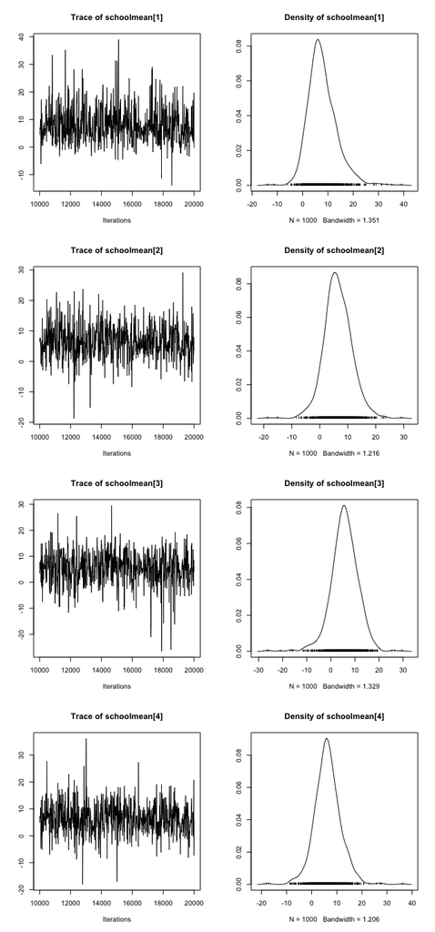

```r
plot(samps.coda[[1]][,2:5])
```

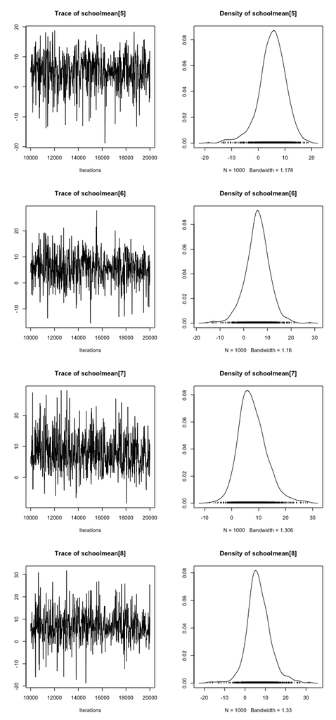

```r
plot(samps.coda[[1]][,6:9])
```

### Simulated RIT Equating Example

OK. So let’s define a simple model is the basis for our simulated data and our probabilistic model of inference. First we’ll assume that there is in fact a latent ability attribute, $\theta_i$, for each student $i \in {1,\dots,.n}$ in our sample. Further, we’ll assume that this latent trait is accurately measured by an *unobserved* RIT score, which we’ll denote $r_{i}$. In other words, RIT scores are a direct measure of $\theta_i$. Luckingly for us, students take a test that gives us an estimate of RIT scores, the MAP. So we assume that the observed RIT, $\hat{r}$ is a realization from a distribution centered on $r$ Finally, we assuem that all other academic measures (interim assessments, Kahn objectives, individual test items, even Do Nows/Exit Tickets). So we have observed realization of a RIT score for a student as well as all the other academic indicators. All other RVs and parameters need to be estimated. And our goal here is to make inferences about $r_i$ given our observation of other acadmeic indicators.

Here’s a graphical representation of our probaility model:

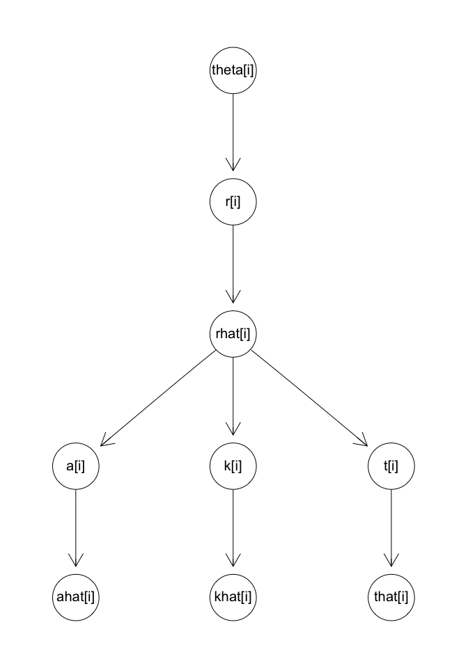

```r
require(Rgraphviz)
rit.graph <- new("graphNEL",
                 nodes=c("theta[i]",
                         "r[i]",
                         "rhat[i]",
                         "a[i]",
                         "k[i]",
                         "t[i]",
                         "ahat[i]",
                         "khat[i]",
                         "that[i]"
                         ),
                 edgemode="directed")

rit.graph <- addEdge("theta[i]", "r[i]", rit.graph, 1)
rit.graph <- addEdge("r[i]", "rhat[i]" , rit.graph, 1)
rit.graph <- addEdge("rhat[i]", "a[i]" , rit.graph, 1)
rit.graph <- addEdge("rhat[i]", "k[i]" , rit.graph, 1)
rit.graph <- addEdge("rhat[i]", "t[i]" , rit.graph, 1)
rit.graph <- addEdge("a[i]", "ahat[i]" , rit.graph, 1)
rit.graph <- addEdge("k[i]", "khat[i]" , rit.graph, 1)
rit.graph <- addEdge("t[i]", "that[i]" , rit.graph, 1)

plot(rit.graph)
```

Now, let’s simulate some data based on this basic probability model. The $\theta_i$’s need a prior and I’ll use the school level norms (because I’m on a plane and don’t have the student level norms with me; we can change these later) for fall 5th grade math. Thinking about this, we can collapse the $\theta_i$s and $r_i$, sunce we are assuming theta exists on the the RIT scale. I’ll use $\theta_i$ to denote the RIT-scaled laten variable.

```r
n <- 90 # number of students
theta<-rnorm(n = n, mean = 211.39, sd =5.83)
```

The $\theta_i$s are then noisily measured by the MAP test. I’ll assume a standard deviation of about 3, but that is completely arbitrary.

```r
rhat<-rnorm(n, theta, sd=rep(3, times=n))

head(rhat)
```

```
## [1] 210.0 208.7 206.1 209.0 207.9 212.4
```

Ok. let’s make some assumptions about how $\hat{r}$ is related to each of the three realizations of our academic indicators. Let’s start with some arbitrary assessment that is graded on a zero to one scale (or zero to 100%) a realization of which is denoted $\hat{a}_i$. We’ll keep it simple and assume that the $\hat{r}_i$ are linear predictors of $z.a_{i}$ in the inverse-logistic function. That is, $z.a_{i} & = \alpha + \beta\hat{r}_{i}$

```r
alpha<- -1
beta<-.01
z.a<- alpha +  beta*rhat
ahat<-1/(1+exp(-z.a))
head(z.a)
```

```
## [1] 1.100 1.087 1.061 1.090 1.079 1.124
```

```r
head(ahat)
```

```
## [1] 0.7503 0.7478 0.7428 0.7483 0.7464 0.7547
```

Let’s pretend, for now, that this the only non-MAP assessment that we have. All we observed are the $\hat{a}_i$